# Algunas recetas para análisis de diversidad genética

En esta clase veremos cómo manejar secuencias desde R/Bioconductor y plantear algunos casos típicos que ocurren en los análisis de diversidad que hacen quienes trabajan en filogenía, genética de poblaciones o mejoramiento genético.

# Paquetes a utilizar

Vamos a precisar varios paquetes para este práctico, incluyendo algunas del proyecto Bioconductor.

Bioconductor (https://bioconductor.org/) es un proyecto basado en R que tiene por objetivo publicar y mantener en forma organizada y sincronizada una gran cantidad de paquetes para bioinformática.

Para poder usar las herramientas de Bioconductor primero hay que instalar el gestor de Bioconductor:

```r
if (!requireNamespace("BiocManager", quietly = TRUE))
   install.packages("BiocManager")
```

Una vez que se completa este paso, se pueden instalar las libraries que necesitemos. Esto se hace una sola vez (por eso el código de abajo está comentado) en la computadora donde estamos trabajando.

Para cada sección vamos a ir instalando o cargando lo que haga falta.

# Alineamientos múltiples y árboles desde R

## Para este ejercicio en particular precisamos:

```r
# BiocManager::install("msa")
```

Además, vamos a precisar algunas bibliotecas de R que sirven para manipular secuencias de nucleótidos y aminoácidos, pero no son parte de Bioconductor. EL código que sigue está comentado porque se ejecuta una sola vez.

```r
# install.packages("seqinr")
# install.packages("phangorn")
```

```r
library(seqinr)
library(msa)
library(phangorn)
```

## Datos a analizar

Para esta práctica vamos a usar algunas secuencias de transcriptos de trigo relacionadas al gen PRB1.2. El nombre del archivo es secuencia_tipo_PRB1_2_trigo.fasta y lo tienen disponible en la carpeta de trabajo de este proyecto.

## Procedimiento general

El archivo fasta que vamos a analizar tiene varias secuencias de transcriptos derivados de genes relacionados entre sí y que codifican para una proteína involucrada en las respuestas de defensa contra patógenos fúngicos.

### Lectura del archivo fasta

En este caso vamos a leer el archivo fasta usando la función *read.fasta()* del paquete *seqinr*

Además de indicar el nombre, tenemos que indicar si es una secuencia de nucleótidos (“DNA”) o de aminoácidos (“AA”). Las secuencias se pueden leer como vectores de caracteres o como un string de múltiples caracteres; en este caso estamos usando la segunda variante.

Con la función *summary()* podemos ver los identificadores de las secuencias y el largo de cada una de ellas, y con *names()* solo los nombres:

```r
summary(prb1)
```

```
                      Length Class       Mode
XM_044586352.1:1-785  785    SeqFastadna character
XM_044580165.1:1-784  784    SeqFastadna character
XM_020324325.3:2-560  559    SeqFastadna character
XM_044586353.1:1-557  557    SeqFastadna character
AK446719.1:1-550      550    SeqFastadna character
MH891152.1:236-792    557    SeqFastadna character
HQ541980.1:2-539      538    SeqFastadna character
AJ007349.1:9-546      538    SeqFastadna character
XM_044570895.1:47-603 557    SeqFastadna character
AB711115.1:1-521      521    SeqFastadna character
XM_037607549.1:4-560  557    SeqFastadna character
KF196294.1:1-521      521    SeqFastadna character
AK446974.1:1-548      548    SeqFastadna character
XM_037604915.1:1-553  553    SeqFastadna character
XM_044580167.1:1-554  554    SeqFastadna character
AK446717.1:1-544      544    SeqFastadna character
HQ541977.1:1-519      519    SeqFastadna character
```

```r
names(prb1)
```

```
 [1] "XM_044586352.1:1-785"  "XM_044580165.1:1-784"  "XM_020324325.3:2-560"
 [4] "XM_044586353.1:1-557"  "AK446719.1:1-550"      "MH891152.1:236-792"
 [7] "HQ541980.1:2-539"      "AJ007349.1:9-546"      "XM_044570895.1:47-603"
[10] "AB711115.1:1-521"      "XM_037607549.1:4-560"  "KF196294.1:1-521"
[13] "AK446974.1:1-548"      "XM_037604915.1:1-553"  "XM_044580167.1:1-554"
[16] "AK446717.1:1-544"      "HQ541977.1:1-519"
```

Y si lo que precisamos es la linea completa de descripción usamos *getAnnot()*

```r
head(prb1_annot)
```

```
[1] ">XM_044586352.1:1-785 PREDICTED: Triticum aestivum pathogenesis-related protein PRB1-2 (LOC543488), transcript variant X1, mRNA"
[2] ">XM_044580165.1:1-784 PREDICTED: Triticum aestivum pathogenesis-related protein PRB1-2-like (LOC123162378), transcript variant X1, mRNA"
[3] ">XM_020324325.3:2-560 PREDICTED: Aegilops tauschii subsp. strangulata pathogenesis-related protein PRB1-2 (LOC109765543), mRNA"
[4] ">XM_044586353.1:1-557 PREDICTED: Triticum aestivum pathogenesis-related protein PRB1-2 (LOC543488), transcript variant X2, mRNA"
[5] ">AK446719.1:1-550 Triticum aestivum mRNA, clone: CK103-F10, cultivar Chinese Spring"
[6] ">MH891152.1:236-792 Triticum aestivum clone OGRS_016827 pathogenesis-related protein PRB1-2-like mRNA, complete cds"
```

Lo que acabamos de hacer es recorrer la lista elemento por elemento y aplicarle la función *unlist()* que “plancha” una lista a un vector.

```r
getLength(prb1)
```

```
 [1] 785 784 559 557 550 557 538 538 557 521 557 521 548 553 554 544 519
```

También con *seqinr* podemos referirnos a una secuencia en particular:

```r
 prb1$`XM_044586353.1:1-557`
```

```
[1] "actcttcatccatctcgagccagctactagctagccatggcatcttccaagagtagtctt…"
attr(,"name")
[1] "XM_044586353.1:1-557"
attr(,"Annot")
[1] ">XM_044586353.1:1-557 PREDICTED: Triticum aestivum pathogenesis-related protein PRB1-2 (LOC543488), transcript variant X2, mRNA"
attr(,"class")
[1] "SeqFastadna"
```

Y recuperar el largo de esta secuencia en particular:

```r
getLength(prb1$`XM_044586353.1:1-557`)
```

```
[1] 557
```

En este punto ya tenemos una buena de la cantidad de secuencias que tenemos para trabajr, también conocemos la distribución de sus largos y a partir de las anotaciones tenemos una idea de sus orígenes y como fueron caracterizadas. Pasemos al segundo paso, el alineaiento

### Construcción de un alineamiento múltiple

Existen diferentes métodos para construir alineamientos múltiples. El método *muscle* es uno bastante rápido y efectivo, y es uno de los que están implementados en el paquete *msa* (msa: multiple sequence alignment).

En primer lugar vamos a leer el mismo archivo que antes, pero ahora con la función *readDNAStringSet()* del paquete *Biostrings*. De esta manera vamos a tener un objeto compatible con las funciones para alinear del paquete *msa*

Veamos qué tenemos:

```r
prb1_bstring
```

```
DNAStringSet object of length 17:
     width seq                                                   names
 [1]   785 GCACTCTTCATCCATCTCGAGCCAG...TGGACAAAACTCCAAAGAACTCTAG XM_044586352.1:1-...
 [2]   784 CACTCTTCATCCATCTCGAGCCACC...GGGACAAAACTCCAAAGAACTCTAG XM_044580165.1:1-...
 [3]   559 GCACTCTTCATCCATCTCGAGCCAG...TCCTCACCCTTGACGCCGAAGCCTA XM_020324325.3:2-...
 [4]   557 ACTCTTCATCCATCTCGAGCCAGCT...TCCTCACCCTTGACGCCGAAGCCTA XM_044586353.1:1-...
 [5]   550 ATCCATCTCGAGCCAGCTACTAGCT...TCCTCACCCTTGACGCCGAAGCCTA AK446719.1:1-550 ...
 ...   ... ...
[13]   548 ATCAATCTCGAGCCACCTACTAGCT...GTTCCTCACCCTTGACGCCGAAGCC AK446974.1:1-548 ...
[14]   553 TCTTCATCAATCTCGAGCCACCTAC...GTTCCTCACCCTTGACGCCGAAGCC XM_037604915.1:1-...
[15]   554 CTCTTCATCCATCTCGAGCCACCTA...GTTCCTTACCCTTGGCGCCGAAGCC XM_044580167.1:1-...
[16]   544 ATCTCGAGCCACCTACTAGCTAGTC...GTTCCTCACCCTTGACGCCGAAGCC AK446717.1:1-544 ...
[17]   519 ATGGCATCTTCCAAGAGCAGTCTTG...GTTCCTCACCCTTGACGCCGAAGCC HQ541977.1:1-519 ...
```

Procedamos con el alineamiento:

```r
prb1_msa <- msa(prb1_bstring, method = "muscle")
```

[output not shown]

La función *msa()* incluye un número importante de parámetros que se corresponden con parámetros del programa *muscle* y así poder ajustar la ejecución del alineamiento. Aquí usamos todas las opciones por defecto. Para más imformación pueden consultar este documento:

http://bioconductor.org/packages/release/bioc/vignettes/msa/inst/doc/msa.pdf

```r
prb1_msa
```

[output not shown]

Para ver el alineamiento completo por pantalla, correr:

```r
print(prb1_msa, show="complete")
```

El paquete *msa* incluye funciones para guardar la salida de este alineamiento para nuestra consulta. Es decir, formateada para facilitar nuestra lectura, pero no para que lo use otro script ni programa. Para más detalles sobre esto, consulten el manual citado más arriba.

```r
matriz_consenso[, 30:42]
```

```
  [,1] [,2] [,3] [,4] [,5] [,6] [,7] [,8] [,9] [,10] [,11] [,12] [,13]
A    0   14    0    0    0   14    0    0    0    17     0     0     0
C    0    0    0   14    0    0    0    6   14     0     0     0     0
G    0    0   14    0    0    0   14    0    0     0     0    17    17
T   14    0    0    0   14    0    0    8    0     0    17     0     0
M    0    0    0    0    0    0    0    0    0     0     0     0     0
R    0    0    0    0    0    0    0    0    0     0     0     0     0
W    0    0    0    0    0    0    0    0    0     0     0     0     0
S    0    0    0    0    0    0    0    0    0     0     0     0     0
Y    0    0    0    0    0    0    0    0    0     0     0     0     0
K    0    0    0    0    0    0    0    0    0     0     0     0     0
V    0    0    0    0    0    0    0    0    0     0     0     0     0
H    0    0    0    0    0    0    0    0    0     0     0     0     0
D    0    0    0    0    0    0    0    0    0     0     0     0     0
B    0    0    0    0    0    0    0    0    0     0     0     0     0
N    0    0    0    0    0    0    0    0    0     0     0     0     0
-    3    3    3    3    3    3    3    3    3     0     0     0     0
+    0    0    0    0    0    0    0    0    0     0     0     0     0
.    0    0    0    0    0    0    0    0    0     0     0     0     0
```

También podemos obtener la secuencia consenso:

```r
secuencia_consenso <- msaConsensusSequence(prb1_msa)
```

La función devuelve un cadena de caracteres. Para ver el consenso entre las posiciones 39 y 80 hacemos:

```r
substring(secuencia_consenso, first = 39, last = 80)
```

```
[1] "ATGGCATCTTCCAAGAGTAGTCTTGCAATGTTCGCACTGGCC"
```

Existen diferentes paquetes de R/Bioconductor que pueden operar con alineamientos. El paquete *msa* tiene una función para hacer conversiones que permiten pasar un alineamiento a otros paquetes. Nosotros vamos a convertir nuestro alineamiento a un objeto de alineamiento de *seqinr* para poder calcular una matriz de distancia y graficar un árbol filogenético.

Y ahora calculamos la matriz de distancia usando una función de identidad sin considerar los gaps entre pares de secuencias. Existen otros paquetes que permiten calcular otras medidas de distancia.

```r
prb1_aln_dist <- dist.alignment(prb1_aln, matrix = "identity", gap = F)
```

```r
prb1_aln_sub <- prb1_aln
for(i in 1:prb1_aln_sub$nb){
  prb1_aln_sub$seq[[i]] <- substring(prb1_aln$seq[[i]], 39, 547)
}
```

```r
prb1_aln_sub$nam
```

```
 [1] "XM_044580165.1:1-784"  "XM_037607549.1:4-560"  "XM_044580167.1:1-554"
 [4] "AJ007349.1:9-546"      "HQ541980.1:2-539"      "XM_044586352.1:1-785"
 [7] "XM_020324325.3:2-560"  "XM_044586353.1:1-557"  "AK446719.1:1-550"
[10] "AB711115.1:1-521"      "KF196294.1:1-521"      "MH891152.1:236-792"
[13] "XM_037604915.1:1-553"  "AK446717.1:1-544"      "XM_044570895.1:47-603"
[16] "AK446974.1:1-548"      "HQ541977.1:1-519"
```

Y ahora calculamos la matriz de distancia de este segundo alineamiento

Nos queda calcular el árbol filogenético. Para esto necesitamos el paquete *ape* que probablemente ya lo tienen instalado. Si este no fuera el caso, correr antes:

```r
# install.packages("ape")
library(ape)
```

Luego:

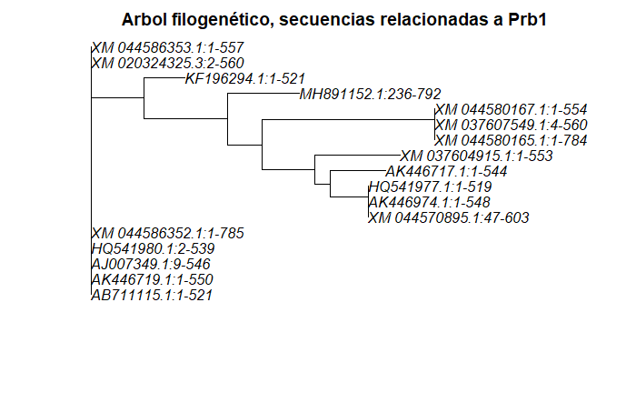

Vamos a guardar este alineamiento en formato fasta:

```r
write.(prb1_aln_sub$seq, names = prb1_aln_sub$nam, file.out = "Prb1_aln_sub.fasta")
```

[output not shown]

# Trabajando con archivos BAM o SAM

Estoy bajando archivos de archivos bam de acá: https://github.com/brainstorm/tiny-test-data/tree/master/wgs

Y un vcf de trigo

```
Genotype trial: Exome Capture 2019 Diversity filtered
Chromosome: chr7D
Start:  162500000
Stop:   162700000
```